# Create dynamic expressions

- 11min
- |
- Terraform

The Terraform configuration language supports complex expressions to allow you to compute or generate values for your infrastructure configuration. Expressions can be simple string or integer values, or more complex values to make your configuration more dynamic.

In this tutorial, you will use expressions to configure and deploy EC2 instances and a load balancer. You will use conditionals to determine whether to provision multiple instances for high-availability and the `splat` expression to return multiple private IPs in your network.

## Prerequisites

You can complete this tutorial using the same workflow with either Terraform Community Edition or HCP Terraform. HCP Terraform is a platform that you can use to manage and execute your Terraform projects. It includes features like remote state and execution, structured plan output, workspace resource summaries, and more.

Select the **HCP Terraform** tab to complete this tutorial using HCP Terraform.

This tutorial assumes that you are familiar with the Terraform workflow. If you are new to Terraform, complete the Get Started tutorials first.

In order to complete this tutorial, you will need the following:

- Terraform v1.1+ installed locally.
- An [AWS account](https://portal.aws.amazon.com/billing/signup?nc2=h_ct&src=default&redirect_url=https%3A%2F%2Faws.amazon.com%2Fregistration-confirmation#/start) with local credentials [configured for use with Terraform](https://registry.terraform.io/providers/hashicorp/aws/latest/docs#authentication).

This tutorial assumes that you are familiar with the Terraform and HCP Terraform workflows. If you are new to Terraform, complete the Get Started tutorials first. If you are new to HCP Terraform, complete the HCP Terraform Get Started tutorials first.

In order to complete this tutorial, you will need the following:

- Terraform v1.1+ installed locally.
- An [AWS account](https://portal.aws.amazon.com/billing/signup?nc2=h_ct&src=default&redirect_url=https%3A%2F%2Faws.amazon.com%2Fregistration-confirmation#/start).
- An [HCP Terraform account](https://app.terraform.io/public/signup/account?utm_source=learn) with HCP Terraform locally authenticated.
- An HCP Terraform variable set configured with your AWS credentials.

## Clone example repository

Clone the [Learn Terraform Expressions](https://github.com/hashicorp-education/learn-terraform-expressions/) repository, which contains configuration for AWS network components, an EC2 instance, and load balancer. You will modify the configuration of these resources using Terraform expressions.

```
$ git clone https://github.com/hashicorp-education/learn-terraform-expressions
```

Navigate to the repository in your terminal.

```
$ cd learn-terraform-expressions
```

## Use a conditional expression

Conditional expressions select a value based on whether the expression evaluates to true or false.

In this configuration, you will use the `locals` block to create a resource name based on a conditional value and capture that name in a map of resource tags.

Open your `main.tf` file and paste in the following code snippet.

main.tf

```
resource "random_id" "id" {
  byte_length = 8
}

locals {
  name  = (var.name != "" ? var.name : random_id.id.hex)
  owner = var.team
  common_tags = {
    Owner = local.owner
    Name  = local.name
  }
}
```

The syntax of a conditional expression first defines the condition, then the outcomes for true and false evaluations. In this example, if `var.name` is not empty (`!= ""`), `local.name` is set to the `var.name` value; otherwise, the name is the `random_id`.

| Condition | ? | true value | : | false value |
| --- | --- | --- | --- | --- |
| If the `name` variable is NOT empty | then | Assign the `var.name` value to the local value | else | Assign `random_id.id.hex` value to the local value |

Next, update the network resources of your configuration and add the `local.common_tags` expression to your `tags` attribute.

Note

Use local values with caution. While reusing a local value simplifies your configuration, it can add complexity to your resource lifecycle.

main.tf

```
resource "aws_vpc" "my_vpc" {
  cidr_block           = var.cidr_vpc
  enable_dns_support   = true
  enable_dns_hostnames = true
  tags                 = local.common_tags
}

resource "aws_internet_gateway" "igw" {
  vpc_id = aws_vpc.my_vpc.id
  tags   = local.common_tags
}

resource "aws_subnet" "subnet_public" {
  vpc_id     = aws_vpc.my_vpc.id
  cidr_block = var.cidr_subnet
  tags       = local.common_tags
}

resource "aws_route_table" "rtb_public" {
  vpc_id = aws_vpc.my_vpc.id

  route {
    cidr_block = "0.0.0.0/0"
    gateway_id = aws_internet_gateway.igw.id
  }
  tags = local.common_tags
}
```

Update your ELB resource with the tags.

main.tf

```
## ...
resource "aws_elb" "learn" {
## ...
  instances                   = aws_instance.ubuntu.id
  idle_timeout                = 400
  connection_draining         = true
  connection_draining_timeout = 400
  tags                        = local.common_tags
}
```

Finally, update your `aws_instance` resource.

main.tf

```
resource "aws_instance" "ubuntu" {
  availability_zone = "us-east-1a"
  ami                         = data.aws_ami.ubuntu.id
  instance_type               = "t2.micro"
  associate_public_ip_address = true
  subnet_id                   = aws_subnet.subnet_public.id
  tags                        = local.common_tags
}
```

Save your changes.

Create a new file called `outputs.tf` and add the values for your instance tags.

outputs.tf

```
output "tags" {
  description = "Instance tags"
  value       = aws_instance.ubuntu.tags
}
```

## Create infrastructure

Initialize this configuration.

```
$ terraform init

Initializing the backend...

Initializing provider plugins...
- Reusing previous version of hashicorp/aws from the dependency lock file
- Reusing previous version of hashicorp/random from the dependency lock file
- Installing hashicorp/aws v4.6.0...
- Installed hashicorp/aws v4.6.0 (signed by HashiCorp)
- Installing hashicorp/random v3.1.2...
- Installed hashicorp/random v3.1.2 (signed by HashiCorp)

Terraform has been successfully initialized!

You may now begin working with Terraform. Try running "terraform plan" to see
any changes that are required for your infrastructure. All Terraform commands
should now work.

If you ever set or change modules or backend configuration for Terraform,
rerun this command to reinitialize your working directory. If you forget, other
commands will detect it and remind you to do so if necessary.
```

Open your `terraform.tf` file and uncomment the `cloud` block. Replace the `organization` name with your own HCP Terraform organization.

terraform.tf

```
terraform {
  cloud {
    organization = "organization-name"
    workspaces {
      name = "learn-terraform-expressions"
    }
  }
  required_providers {
    aws = {
      source  = "hashicorp/aws"
      version = "~> 4.4.0"
    }
  }
  required_version = ">= 1.1"
}
```

Initialize your configuration. Terraform will automatically create the `learn-terraform-expressions` workspace in your HCP Terraform organization.

```
$ terraform init
Initializing HCP Terraform...
Initializing provider plugins...
- Reusing previous version of hashicorp/aws from the dependency lock file
- Installing hashicorp/aws v4.4.0...
- Installed hashicorp/aws v4.4.0 (signed by HashiCorp)
HCP Terraform has been successfully initialized!
You may now begin working with HCP Terraform. Try running "terraform plan" to
see any changes that are required for your infrastructure.
If you ever set or change modules or Terraform Settings, run "terraform init"
again to reinitialize your working directory.
```

Note

This tutorial assumes that you are using a tutorial-specific HCP Terraform organization with a global variable set of your AWS credentials. Review the Create a Credential Variable Set for detailed guidance. If you are using a scoped variable set, [assign it to your new workspace](https://developer.hashicorp.com/terraform/cloud-docs/workspaces/variables/managing-variables#apply-or-remove-variable-sets-from-inside-a-workspace) now.

Run `terraform apply`. Respond `yes` to the prompt to confirm the operation.

```
$ terraform apply

Terraform used the selected providers to generate the following execution plan. Resource actions are
indicated with the following symbols:
  + create

Terraform will perform the following actions:
##...
Do you want to perform these actions?
  Terraform will perform the actions described above.
  Only 'yes' will be accepted to approve.

  Enter a value: yes
##...
Apply complete! Resources: 8 added, 0 changed, 0 destroyed.

Outputs:

tags = tomap({
  "Name" = "terraform"
  "Owner" = "hashicorp"
})
```

Tip

This tutorial shows the output for Terraform commands run with the Terraform CLI. If you are following the HCP Terraform workflow, the output may differ slightly but the results will be the same.

If you use HCP Terraform to provision your resources, your workspace now displays the list of all of the resources it manages.

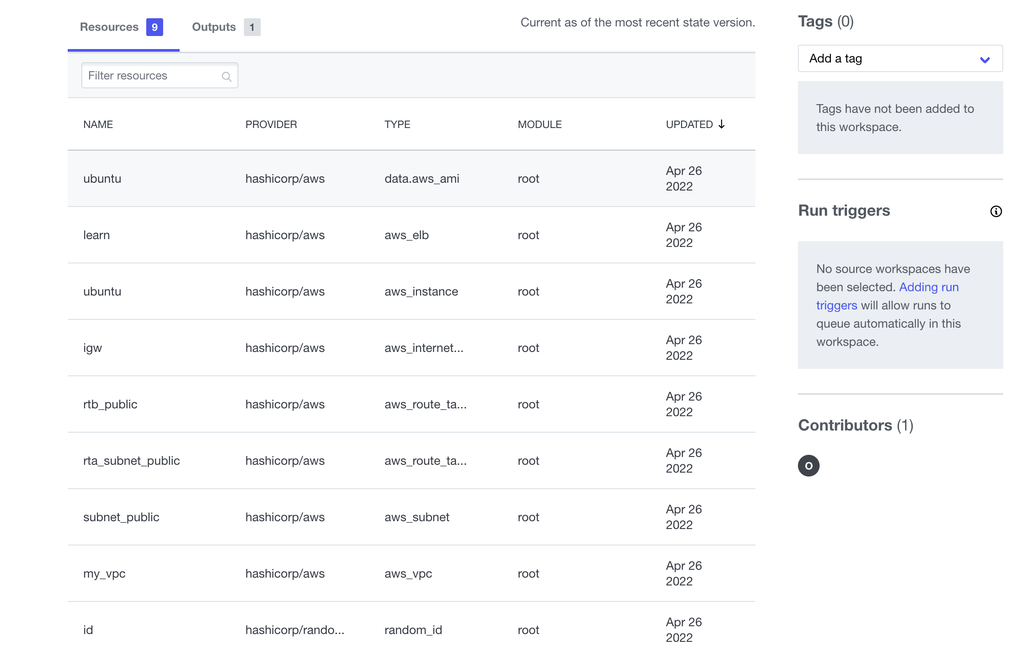

The Terraform outputs contain the formatted resource tags.

## Create a conditional count criteria

Open `variables.tf` and add a new boolean variable for high availability.

variables.tf

```
variable "high_availability" {
  type        = bool
  description = "If this is a multiple instance deployment, choose `true` to deploy 3 instances"
  default     = true
}
```

Save this file.

Next, open `main.tf` and update the `aws_instance` resource to use the new `high_availability` variable.

First, update the count parameter with a conditional expression based on the value of `var.high_availability`. Then update the `associate_public_ip_address` parameter so that only the first instance is assigned a public IP address. Finally, merge the tags for the new instances.

main.tf

```
resource "aws_instance" "ubuntu" {
  count                       = (var.high_availability == true ? 3 : 1)
  ami                         = data.aws_ami.ubuntu.id
  instance_type               = "t2.micro"
  associate_public_ip_address = (count.index == 0 ? true : false)
  subnet_id                   = aws_subnet.subnet_public.id
  tags                        = merge(local.common_tags)
}
```

| Condition | ? | true value | : | false value |
| --- | --- | --- | --- | --- |
| If `var.high_availability` is set to true | then | Create three `aws_instance` resources | else | Create one `aws_instance` resource |
| If `count.index` is 0 | then | Assign public IP | else | Do not assign public IP |

Save your changes.

## Use a `splat` expression

The `aws_instance` resource could now have a count value of `3`. To return the private IP addresses of all of the instances, you will use a splat `*` expression to create an output value.

The `splat` expression captures all objects in a list that share an attribute. The special `*` symbol iterates over all of the elements of a given list and returns information based on the shared attribute you define.

Without the splat expression, Terraform would not be able to output the entire array of your instances and would only return the first item in the array.

### Create a splat expression

Edit the `outputs.tf` file to add the new `private_addresses` output. This output will return the private DNS of all instances created by the `aws_instance.ubuntu` resource.

outputs.tf

```
output "private_addresses" {
  description = "Private DNS for AWS instances"
  value       = aws_instance.ubuntu[*].private_dns
}
```

This expression mirrors capturing a specific element in an array. If you only wanted to return the third instance IP in the array of instances, you could do that by replacing the `*` with `2`.

The current `tags` output will error because there are multiple instances.

**Replace** the `tags` output block with the following `first_tags` output, which will return the first instance's tags.

outputs.tf

```
output "first_tags" {
  description = "Instance tags for first instance"
  value       = aws_instance.ubuntu[0].tags
}
```

Open `main.tf` to add the new instances to the ELB configuration.

main.tf

```
resource "aws_elb" "learn" {
##...
  instances                   = aws_instance.ubuntu[*].id
  idle_timeout                = 400
  connection_draining         = true
  connection_draining_timeout = 400
  tags                        = local.common_tags
}
```

Save your changes.

### Apply your changes

Run `terraform apply` to provision the new instances and update your load balancer configuration. Respond `yes` to the prompt to confirm the operation.

```
$ terraform apply
random_id.id: Refreshing state... [id=NfgSYKxrorA]
aws_vpc.my_vpc: Refreshing state... [id=vpc-06e45b1a591e2b96f]
aws_internet_gateway.igw: Refreshing state... [id=igw-05972512ea18f8eb0]
aws_subnet.subnet_public: Refreshing state... [id=subnet-0f0710e956d144ac3]
aws_route_table.rtb_public: Refreshing state... [id=rtb-002b2df72a5eee2ba]
aws_instance.ubuntu[0]: Refreshing state... [id=i-08ff118d23a9cddc4]
aws_route_table_association.rta_subnet_public: Refreshing state... [id=rtbassoc-0d692f2cd308ef864]
aws_elb.learn: Refreshing state... [id=Learn-ELB]

Terraform used the selected providers to generate the following execution plan. Resource actions are
indicated with the following symbols:
  + create
  ~ update in-place

Terraform will perform the following actions:
##...
Do you want to perform these actions?
  Terraform will perform the actions described above.
  Only 'yes' will be accepted to approve.

  Enter a value: yes
##...

Apply complete! Resources: 2 added, 1 changed, 0 destroyed.

Outputs:

first_tags = tomap({
  "Name" = "terraform"
  "Owner" = "hashicorp"
})
private_addresses = [
  "ip-172-16-10-133.us-east-2.compute.internal",
  "ip-172-16-10-244.us-east-2.compute.internal",
  "ip-172-16-10-63.us-east-2.compute.internal",
]
```

Terraform's output now contains the entire array of private addresses for all three EC2 instances.

## Clean up resources

After verifying that the resources were deployed successfully, run `terraform destroy` to destroy them. Respond `yes` to the confirmation prompt to confirm the action.

```
$ terraform destroy
random_id.id: Refreshing state... [id=NfgSYKxrorA]
aws_vpc.my_vpc: Refreshing state... [id=vpc-06e45b1a591e2b96f]
aws_internet_gateway.igw: Refreshing state... [id=igw-05972512ea18f8eb0]
aws_subnet.subnet_public: Refreshing state... [id=subnet-0f0710e956d144ac3]
aws_route_table.rtb_public: Refreshing state... [id=rtb-002b2df72a5eee2ba]
aws_instance.ubuntu[0]: Refreshing state... [id=i-08ff118d23a9cddc4]
aws_instance.ubuntu[1]: Refreshing state... [id=i-0f4ef22bcf35a2632]
aws_instance.ubuntu[2]: Refreshing state... [id=i-0566759e2fd7116d7]
aws_route_table_association.rta_subnet_public: Refreshing state... [id=rtbassoc-0d692f2cd308ef864]
aws_elb.learn: Refreshing state... [id=Learn-ELB]

Terraform used the selected providers to generate the following execution plan. Resource actions are
indicated with the following symbols:
  - destroy

Terraform will perform the following actions:
##...
Do you really want to destroy all resources?
  Terraform will destroy all your managed infrastructure, as shown above.
  There is no undo. Only 'yes' will be accepted to confirm.

  Enter a value: yes
##...
Destroy complete! Resources: 10 destroyed.
```

If you used HCP Terraform for this tutorial, after destroying your resources, delete the `learn-terraform-expressions` workspace from your HCP Terraform organization.

## Next steps

To learn more about how to create more complex, dynamic configuration, review the following resources:

- Learn how to use local values to simplify your configuration.
- Review how to use functions for computations in your configuration.
- Explore how to customize your configuration using input variables.

Previous

Functions

Next

Provider versions

© 2026 HashiCorp  
Licensed under the MPL 2.0 License.  
https://developer.hashicorp.com/terraform/tutorials/configuration-language/expressions?utm_source=WEBSITE&utm_medium=WEB_IO&utm_offer=ARTICLE_PAGE&utm_content=DOCS